# DSS Customers By Year - Age Class Code Report

## SUMMARY OF DATA ELEMENT

| value | description |
| --- | --- |
| 1 | Child |
| 2 | Adult |
| 90 | Not valid |
| 91 | Source blank |

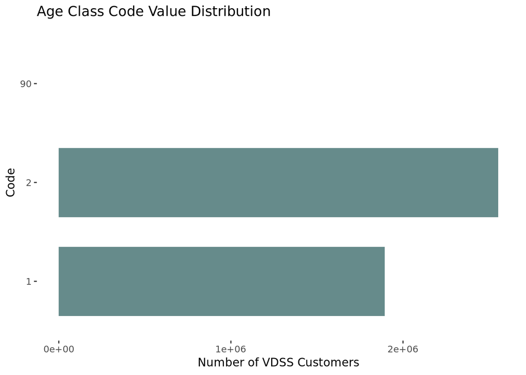

## DATA ANALYTICS SUMMARY OF RESULTS

| Test | Measurementvalues | Value |
| --- | --- | --- |
| Completeness | Number of missing values | 0 |
|  | Percent of complete values | 100 % |
| Validity | Number of invalid values | 18 |
|  | Percent of valid values | 99.99 % |
| Uniqueness | Number of unique values | 3 |
| Record Consistency I | Number of inconsistent records | 0 |
|  | Percent consistent records | 100 % |
| Record Consistency II | Number of inconsistent records | 0 |
|  | Percent consistent records | 100 % |
| Record Consistency III | Number of inconsistent records | 13 |
|  | Percent consistent records | 99.99 % |
| Longitudinal Inconsistency I | Individuals with inconsistent records | NA |
|  | Percent individuals with consistent records | NA % |

## UNIQUENESS

### A frequency distribution of values for Age Class Code .

A basic Age Class Code distribution plot is shown giving the frequency of the values 1, 2, 90, 91 occuring in the dataset.  
**Number of unique values 3**

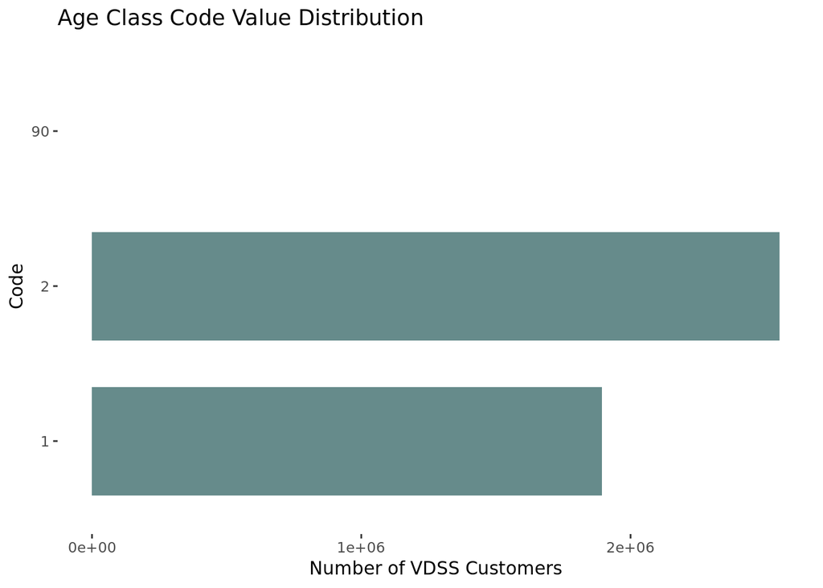

```r
values <-  cust_by_yr[!is_blank(age_class_code), age_class_code]

unique_values <-
  length(unique(values))

# frequency distribution table of active_status values
frequencies = as.data.frame(table(values))

# frequency distribution plot of active_status values
ggplot(frequencies, aes(values, Freq)) +
  geom_bar(stat="identity", fill ="paleturquoise4", width=.7) +
  coord_flip() +ggtitle(paste(column_name_print, "Value Distribution")) +
  xlab("Code") +
  ylab("Number of VDSS Customers") +
  theme(panel.background=element_blank())
```

```r
print(frequencies)
```

```
##   values    Freq
## 1      1 1893370
## 2      2 2553630
## 3     90      18
```

## COMPLETENESS

### Find records with missing values for Age Class Code .

The completeness of the data simply refers to whether or not there are missing or NULL values. Whether or not the values should be missing or null is genrally determined when assessing record consistency. In the case of Age Class Code there should be no missing values.  
**Number Missing 0**  
**Percent Complete 100 %**

```r
missing <- cust_by_yr[is_blank(age_class_code), .N]

print(missing)
```

```
## [1] 0
```

```r
#give the total count of responses
print(total_record_count, row.names = FALSE)
```

```
## [1] 4447018
```

```r
#calculate the percent of the variable which is complete
percent_complete <-
  truncate(((total_record_count - missing)/total_record_count)*100, prec = 2)

print(percent_complete, row.names = FALSE)
```

```
## [1] 100
```

## VALUE VALIDITY

### Find records with invalid values for Age Class Code .

```r
invalid = cust_by_yr[is_blank(age_class_code)|age_class_code %in% c("90", "91"), .N]

# get number of rows with invlaid values for active_status
print(invalid)
```

```
## [1] 18
```

```r
# give the total count of responses
print(total_record_count, row.names = FALSE)
```

```
## [1] 4447018
```

```r
# calculate the percent of the variable which is valid
percent_valid = truncate(((total_record_count - invalid)/total_record_count)*100, prec = 2)
print(percent_valid, row.names = FALSE)
```

```
## [1] 99.99
```

```r
if (invalid > 0){
# get record details
  invalid_details <-
    cust_by_yr[is_blank(age_class_code)|age_class_code %in% c("90", "91"), c("unique_id", "age_class_code", "age_group_code", "age_type_code" , "calender_year_number", "year_of_birth")]
 print(invalid_details)
}
```

```
##     unique_id age_class_code age_group_code age_type_code
##  1:   ZTYZAQQ             90             90            90
##  2:   2NL9QQQ             90             90            90
##  3:   C6TTAQQ             90             90            90
##  4:   2VT4AQQ             90             90            90
##  5:   FHLYQQQ             90             90            90
##  6:   9NQKQQQ             90             90            90
##  7:   4QRMQQQ             90             90            90
##  8:   TEDMQQQ             90             90            90
##  9:   BSYSQQQ             90             90            90
## 10:   X34XAQQ             90             90            90
## 11:   EV78QQQ             90             90            90
## 12:   XZMJQQQ             90             90            90
## 13:   NLA4AQQ             90             90            90
## 14:   DDQCAQQ             90             90            90
```

[output cut: 23 more lines]

## RECORD CONSISTENCY I

### Find Records with an inconsistent relationship between Age Class Code and Age Group Code .

Check where records with age class 90 or 91 have non-matching values in Age Group Code.  
**Number Inconsistent: 0**  
**Percent Consistent: 100 %**

```r
# create a list of the other columns to which the column is being compared
record_inconsistent_compare_columns_1 <- "Age Group Code"

# consistency check definition
record_inconsistent_compare_1_definition <-
  "Check where records with age class 90 or 91 have non-matching values in Age Group Code."

# get inconsistent records
record_inconsistent_1 <-
  cust_by_yr[age_class_code %in% c("90", "91"), ][!age_group_code %in% c("90", "91"), ][ ,.N]

print(record_inconsistent_1)
```

```
## [1] 0
```

```r
# give the total count of responses
print(total_record_count)
```

```
## [1] 4447018
```

```r
# calculate the percent of the variable which is consistent
record_percent_consistent_1 <-
  truncate(((total_record_count - record_inconsistent_1)/total_record_count)*100, prec = 2)

print(record_percent_consistent_1)
```

```
## [1] 100
```

```r
if (record_inconsistent_1 > 0){
# get record details
  record_inconsistent_1_details <-
    cust_by_yr[age_class_code %in% c("90", "91"), ][!age_group_code %in% c("90", "91"), ][ , c("age_class_code", "age_group_code")]


  # read in data
  year_plot_df <-
    as.data.frame(
      table(record_inconsistent_1_details[[1]], record_inconsistent_1_details[[2]], exclude=NULL), na.rm=FALSE)

  # levels(year_plot_df$Var2) <-c("2013","2014","2015","2016")


# plot inconsistencies by Age Group
  age_group <- (ggplot(
    year_plot_df, aes(Var2, Freq)) +
    geom_bar(stat="identity", fill ="honeydew3", width=.7) +
    ggtitle("Inconsistent Record Entry by Age Group") +
    ylab("Age Group") +
    scale_x_discrete("Age Class", drop = "FALSE") +
    theme(panel.background=element_blank()))

  print(age_group)
  print(year_plot_df)

  }
```

## RECORD CONSISTENCY II

### Find Records with an inconsistent relationship between Age Class Code and Age Type .

Check where records with age class 90 or 91 have non-matching values in Age Type Code.  
**Number Inconsistent: 0**  
**Percent Consistent: 100 %**

```r
# create a list of the other columns to which the column is being compared
record_inconsistent_compare_columns_2 <- c("Age Type")

# consistency check definition
record_inconsistent_compare_2_definition <-
  "Check where records with age class 90 or 91 have non-matching values in Age Type Code."

# get inconsistent records
record_inconsistent_2 <-
  cust_by_yr[age_class_code %in% c(90,91)][!age_type_code %in% c(90, 91)][,.N]

print(record_inconsistent_2)
```

```
## [1] 0
```

```r
# give the total count of responses
print(total_record_count)
```

```
## [1] 4447018
```

```r
# calculate the percent of the variable which is consistent
record_percent_consistent_2 <-
  truncate(((total_record_count - record_inconsistent_2)/total_record_count)*100, prec = 2)

print(record_percent_consistent_2)
```

```
## [1] 100
```

```r
if (record_inconsistent_2 > 0){
# get record details
  record_inconsistent_2_details <-
    cust_by_yr[age_class_code %in% c(90,91)][!age_type_code %in% c(90, 91)][ , c("age_class_code", "age_type_code")]

  # read in data
  year_plot_df <-
    as.data.frame(
      table(record_inconsistent_2_details[[1]], record_inconsistent_2_details[[2]]))

  # plot inconsistencies by School Year
  age_type <- (ggplot(
    year_plot_df, aes(Var2, Freq)) +
    geom_bar(stat="identity", fill ="honeydew3", width=.7) +
    ggtitle("Inconsistent Record Entry by Age Type") +
    ylab("Age Type") +
    scale_x_discrete("Age Class", drop = "FALSE") +
    theme(panel.background=element_blank()))

  #  theme(text=element_text(size=10), axis.text.x=element_text(angle=90, vjust=1))) +
  #  theme(axis.text.x = element_text(angle=90, vjust=0.5, size=2))

  print(age_type)
  print(table(year_plot_df))

}
```

## RECORD CONSISTENCY III

### Find Records with an inconsistent relationship between Age Class Code and Year of Birth .

Check where records with age class 90 or 91 have valid values in Year of Birth (>1900).  
**Number Inconsistent: 13**  
**Percent Consistent: 99.99 %**

```r
# create a list of the other columns to which the column is being compared
record_inconsistent_compare_columns_3 <- c("Year of Birth")

# consistency check definition
record_inconsistent_compare_3_definition <-
  "Check where records with age class 90 or 91 have valid values in Year of Birth (>1900)."

# get inconsistent records
record_inconsistent_3 <-
  cust_by_yr[age_class_code %in% c(90,91)][as.integer(year_of_birth) <= 1900, ][,.N]

print(record_inconsistent_3)
```

```
## [1] 13
```

```r
# give the total count of responses
print(total_record_count)
```

```
## [1] 4447018
```

```r
# calculate the percent of the variable which is consistent
record_percent_consistent_3 <-
  truncate(((total_record_count - record_inconsistent_3)/total_record_count)*100, prec = 2)

print(record_percent_consistent_3)
```

```
## [1] 99.99
```

```r
if (record_inconsistent_2 > 0){
# get record details
  record_inconsistent_3_details <-
    cust_by_yr[age_class_code %in% c(90,91)][as.integer(year_of_birth) <= 1900, ][ , c("age_class_code", "year_of_birth")]

  # read in data
  b_year_plot_df <-
    as.data.frame(
      table(record_inconsistent_3_details[[1]], record_inconsistent_3_details[[2]]))

  # plot inconsistencies by School Year
  birth_year <- (ggplot(
    year_plot_df, aes(Var2, Freq)) +
    geom_bar(stat="identity", fill ="honeydew3", width=.7) +
    ggtitle("Inconsistent Record Entry by Year of Birth") +
    ylab("Year of Birth") +
    scale_x_discrete("Age Class", drop = "FALSE") +
    theme(panel.background=element_blank()))

  #  theme(text=element_text(size=10), axis.text.x=element_text(angle=90, vjust=1))) +
  #  theme(axis.text.x = element_text(angle=90, vjust=0.5, size=2))

  print(birth_year)
  print(table(b_year_plot_df))

}
```